# Baton Rouge Crime Analysis

## Project Overview

This project analyzes reported crime incidents in Baton Rouge, focusing on violent crime trends by neighborhood and over time.

## Tools

Python, pandas, NumPy, matplotlib

```python
import pandas as pd
import numpy as np
import matplotlib.pyplot as plt
import os
```

```python
os.chdir("C:/Users/User/DataSets")
crime = pd.read_csv("BRcrime.csv")
crime.head()
```

|  | INCIDENT NUMBER | CHARGE ID | CHARGE DATE | REPORT DATE | APPROVED DATE | ATTEMPTED OR COMMITTED | STREET ADDRESS | SUBADDRESS | CITY | STATE | ... | CRIME AGAINST | NIBRS CODE | NIBRS DESCRIPTION | CENSUS BLOCK GROUP | COUNCIL DISTRICT | CRIME PREVENTION DISTRICT | NEIGHBORHOOD | LONGITUDE | LATITUDE | GEOLOCATION |
| --- | --- | --- | --- | --- | --- | --- | --- | --- | --- | --- | --- | --- | --- | --- | --- | --- | --- | --- | --- | --- | --- |
| 0 | 20-064980 | 8FBB0B74-A66F-45A0-A3F7-BF8136FB3454 | 07/26/2020 02:27:00 PM | 10/21/2021 10:03:02 AM | 10/25/2021 03:02:14 PM | COMMITTED | NaN | NaN | NaN | LA | ... | NaN | NaN | NaN | NaN | 10.0 | NaN | SOUTH CAMPUS | NaN | NaN | NaN |
| 1 | 19-082654 | AFF2B61F-AC22-46D5-982D-3CA140D57369 | 09/08/2019 03:08:00 AM | 07/14/2021 01:51:06 PM | 07/29/2021 09:00:41 AM | COMMITTED | NaN | NaN | NaN | NaN | ... | NaN | NaN | NaN | NaN | NaN | NaN | NaN | NaN | NaN | NaN |
| 2 | 26-102067 | 3865895 | 01/07/2026 01:51:00 PM | 01/07/2026 01:50:32 PM | 02/01/2026 06:43:19 PM | COMPLETED | 358 E INTERSTATE 12 HWY | NaN | BATON ROUGE | LA | ... | SOCIETY | 520 | WEAPON LAW VIOLATIONS | NaN | NaN | NaN | NaN | NaN | NaN | NaN |
| 3 | 20-015556 | 8929E25E-778E-44C0-9387-70ADBD1F02C1 | 02/18/2020 02:28:00 PM | 02/10/2021 10:05:30 AM | 02/10/2021 02:25:17 PM | COMMITTED | NaN | NaN | NaN | NaN | ... | NaN | NaN | NaN | NaN | NaN | NaN | NaN | NaN | NaN | NaN |
| 4 | 20-081894 | 2B92E71D-B300-4746-B8D9-A6E3D13A9A05 | 09/16/2020 02:50:00 PM | 05/14/2021 10:21:19 AM | 05/17/2021 06:26:20 AM | COMMITTED | NaN | NaN | NaN | NaN | ... | NaN | NaN | NaN | NaN | NaN | NaN | NaN | NaN | NaN | NaN |

5 rows × 27 columns

```python
crime.info()
```

```
<class 'pandas.core.frame.DataFrame'>
RangeIndex: 190534 entries, 0 to 190533
Data columns (total 27 columns):
 #   Column                     Non-Null Count   Dtype
---  ------                     --------------   -----
 0   INCIDENT NUMBER            190532 non-null  object
 1   CHARGE ID                  190534 non-null  object
 2   CHARGE DATE                190534 non-null  object
 3   REPORT DATE                190534 non-null  object
 4   APPROVED DATE              190534 non-null  object
 5   ATTEMPTED OR COMMITTED     188057 non-null  object
 6   STREET ADDRESS             166024 non-null  object
 7   SUBADDRESS                 5176 non-null    object
 8   CITY                       188855 non-null  object
 9   STATE                      188977 non-null  object
```

[output cut: 19 more lines]

Before cleaning, categorical fields are investigated to understand the datset structure.

```python
crime['CRIME AGAINST'].value_counts()
```

```
CRIME AGAINST
PROPERTY                       93746
PERSON                         41076
SOCIETY                        26257
PERSON, PROPERTY,OR SOCIETY    12841
Property                         457
Society                           31
Person                            18
PERSON/NOT A CRIME                11
NOT A CRIME                        1
Name: count, dtype: int64
```

```python
crime['NIBRS DESCRIPTION'].value_counts().head(10)
```

```
NIBRS DESCRIPTION
SIMPLE ASSAULT                              20947
DESTRUCTION/DAMAGE/VANDALISM OF PROPERTY    17487
BURGLARY/BREAKING & ENTERING                14253
ALL OTHER LARCENY                           13381
ALL OTHER OFFENSES                          12841
AGGRAVATED ASSAULT                          12368
SHOPLIFTING                                 10820
THEFT FROM MOTOR VEHICLE                    10573
MOTOR VEHICLE THEFT                          9390
WEAPON LAW VIOLATIONS                        8326
Name: count, dtype: int64
```

```python
crime['NEIGHBORHOOD'].value_counts().head(10)
```

```
NEIGHBORHOOD
NORTH BATON ROUGE        13452
SCOTLANDVILLE            10295
OLD SOUTH BATON ROUGE     9888
JONES CREEK               9813
BROOKSTOWN                9688
MID CITY                  8190
SOUTH CAMPUS              8145
DELMONT PLACE             7168
NORTH SHERWOOD FOREST     7074
ISTROUMA / DIXIE          6361
Name: count, dtype: int64
```

The CRIME AGAINST column contains inconsistent and duplicate category labels, which will need to be standardized to ensure accurate analysis.

The NIBRS descriptions show a wide range of specific crime types, suggesting that the dataset captures a diverse set of offenses that can be analyzed in more detail beyond broad categories. Options show a wide range of crime types have been reported in Baton Rouge, across multiple distinct neighborhoods.

## Data Cleaning

To prepare the dataset for analysis, several steps were taken to consolidate redundant columns and standardize categorical values.

```python
crime['STATUTE'] = (
    crime['STATUTE CATEGORY']
    .fillna(crime['STATUTE DESCRIPTION'])
    .fillna(crime['STATUTE TITLE'])
)

crime['NIBRS'] = (
    crime['NIBRS DESCRIPTION']
    .fillna(crime['NIBRS CODE'])
)
```

```python
crime = crime.drop(columns=[
    'STATUTE DESCRIPTION',
    'STATUTE TITLE',
    'NIBRS CODE',
    'STATUTE CATEGORY',
    'NIBRS DESCRIPTION'
])
```

```python
def categorize(value):


    if pd.isna(value):
        return "OTHER"


    elif "PERSON" in value:
        return "PERSON"


    elif "PROPERTY" in value:
        return "PROPERTY"

    elif "SOCIETY" in value:
        return "SOCIETY"

    else:
        return "OTHER"

crime['CRIME AGAINST CLEAN'] = crime['CRIME AGAINST'].apply(categorize)
```

```python
crime = crime.drop(columns= ['CRIME AGAINST'])

crime = crime.rename(columns={'CRIME AGAINST CLEAN' : 'CRIME AGAINST'})
```

Redundant columns containing overlapping information were consolidated to simplify the dataset and improve consistency. All columns related to statute information were merged into a single STATUTE column, while NIBRS DESCRIPTION and NIBRS CODE were combined into a unified NIBRS column. The original fragmented columns were then removed to reduce duplication and ensure each variable was represented clearly.

The CRIME AGAINST column contained inconsistent and overlapping labels. To standardize this variable, values were grouped into four categories: PERSON, PROPERTY, SOCIETY, and OTHER. This transformation allows for more consistent comparison of crime types across neighborhoods and over time. The original column was replaced with the cleaned and standardized version.

Additional cleaning was performed to ensure that the dataset only includes incidents reported within Baton Rouge, Louisiana.

```python
crime = crime[ crime['STATE'] == 'LA' ]

crime['CITY'] = crime['CITY'].str.strip()
crime['CITY'] = crime['CITY'].replace({ 'BATON ROUGE': 'BATON ROUGE', 'BATON ROGUE': 'BATON ROUGE', 'BR': 'BATON ROUGE', 'B.R.': 'BATON ROUGE', 'BATON': 'BATON ROUGE' })
crime = crime[crime['CITY'] == 'BATON ROUGE']

crime = crime.drop(columns=['STATE', 'CITY', 'GEOLOCATION', 'CENSUS BLOCK GROUP'])
```

Although the dataset is labeled as representing Baton Rouge, Louisiana, records from other states were present. To ensure geographic accuracy, the dataset was first filtered to include only incidents reported within Louisiana.

The CITY column contained inconsistently labeled values (e.g., abbreviations and misspellings), which were standardized prior to filtering. After standardization, only records from Baton Rouge were retained. This ensures that all observations in the dataset are relevant to the intended area of analysis.

Once the dataset was restricted to Baton Rouge, the STATE and CITY columns were removed, as they no longer provided additional analytical value. Additional columns, including GEOLOCATION and CENSUS BLOCK GROUP, were also dropped due to redundancy or limited relevance to the scope of this project.

The CHARGE DATE column was converted to a datetime format to enable time-based analysis. From this column, YEAR and MONTH features were extracted to support trend analysis over time. The dataset was then filtered to include only recent years (2020–2025) to focus on the most complete and relevant data.

```python
crime['CHARGE DATE'] = pd.to_datetime(crime['CHARGE DATE'])

crime['YEAR'] = crime['CHARGE DATE'].dt.year
crime['MONTH'] = crime['CHARGE DATE'].dt.month

crime = crime[crime['YEAR'] >= 2020]
crime = crime[crime['YEAR'] < 2026]
```

The original dataset does not explicitly distinguish between violent and non-violent offenses. To enable focused analysis, a separate dataframe was created containing only crimes classified as violent.

For this project, violent crime is defined as offenses involving direct harm or threat to another person. Both STATUTE and NIBRS classifications were used to identify relevant offenses, including assault, homicide, robbery, and related categories.

```python
violent_statutes = [
    "BATTERY",
    "ASSAULT",
    "HOMICIDE",
    "SEXUAL ASSAULT",
    "INDIVIDUAL ROBBERY",
    "AGGRAVATED ROBBERY",
    "KIDNAPPING",
]

violent_nibrs = [
    "SIMPLE ASSAULT",
    "AGGRAVATED ASSAULT",
    "ROBBERY",
    "INTIMIDATION",
    "KIDNAPPING/ABDUCTION",
    "FORCIBLE RAPE",
    "FORCIBLE FONDLING",
    "MURDER & NONNEGLIGENT MANSLAUGHTER"
]

exclude_statutes = ["OTHER", "NUISANCE", "TRAFFIC", "JUVENILE"]


violent = crime[
    (
        (crime["STATUTE"].isin(violent_statutes)) |
        (crime["NIBRS"].isin(violent_nibrs))
    )
    &
    (~crime["STATUTE"].isin(exclude_statutes))
]
violent = violent[~violent["NIBRS"].str.contains("ALL OTHER OFFENSES", na=False)]

violent['NIBRS'].value_counts().head(10)
```

```
NIBRS
SIMPLE ASSAULT                              18562
AGGRAVATED ASSAULT                          10723
WEAPON LAW VIOLATIONS                        3174
ROBBERY                                      2817
MURDER & NONNEGLIGENT MANSLAUGHTER           1474
INTIMIDATION                                  645
FORCIBLE RAPE                                 584
KIDNAPPING/ABDUCTION                          541
FORCIBLE FONDLING                             484
DESTRUCTION/DAMAGE/VANDALISM OF PROPERTY      170
Name: count, dtype: int64
```

Violent crime patterns were analyzed across neighborhoods to identify areas with both high crime volume and a high proportion of violent incidents.

Total crimes and violent crimes were calculated for each neighborhood, and a proportion of violent crime was derived by comparing the two. To ensure meaningful comparisons, neighborhoods with very low total crime counts were excluded.

A combined metric was then created to highlight neighborhoods with both high crime volume and a high concentration of violent offenses, allowing for more balanced comparison across areas.

```python
total = crime.groupby("NEIGHBORHOOD").size()
violent_counts = violent.groupby("NEIGHBORHOOD").size()

combo = pd.DataFrame({
    'total': total,
    'violent': violent_counts
}).fillna(0)

combo['proportion'] = combo['violent'] / combo['total']

combo_filtered = combo[combo['total'] > 100].copy()

combo_filtered['score'] = combo_filtered['proportion'] * combo_filtered['total']

combo_filtered.sort_values(by='score', ascending=False).head(10)
```

| NEIGHBORHOOD | total | violent | proportion | score |
| --- | --- | --- | --- | --- |
| NORTH BATON ROUGE | 12908 | 3496.0 | 0.270840 | 3496.0 |
| BROOKSTOWN | 9293 | 2578.0 | 0.277413 | 2578.0 |
| SCOTLANDVILLE | 9944 | 2483.0 | 0.249698 | 2483.0 |
| OLD SOUTH BATON ROUGE | 9502 | 2059.0 | 0.216691 | 2059.0 |
| JONES CREEK | 9469 | 1873.0 | 0.197803 | 1873.0 |
| NORTH SHERWOOD FOREST | 6805 | 1825.0 | 0.268185 | 1825.0 |
| DELMONT PLACE | 6919 | 1701.0 | 0.245845 | 1701.0 |
| MID CITY | 7805 | 1555.0 | 0.199231 | 1555.0 |
| ISTROUMA / DIXIE | 6154 | 1541.0 | 0.250406 | 1541.0 |
| DOWNTOWN EAST | 5238 | 1396.0 | 0.266514 | 1396.0 |

Neighborhood-level analysis shows variation in the share of violent crime across Baton Rouge. North Baton Rouge stands out due to a combination of high total crime volume and a relatively high proportion of violent incidents, making it a key area of concern.

Because this neighborhood has a large number of total reported crimes, its estimated proportion of violent crime is more stable and reliable than neighborhoods with smaller sample sizes. Across the top neighborhoods, the share of violent crime generally falls in the range of approximately 19% to 27%, indicating meaningful differences in crime composition between areas.

## Visualizations and Interpretation

The neighborhood with the highest combined burden of violent crime, considering both total volume and proportion, is North Baton Rouge. A line chart was created to visualize the proportion of violent crime over time within this neighborhood.

The neighborhood with the second highest combined score is Brookstown. A second line representing violent crime rates in Brookstown was plotted alongside North Baton Rouge to allow for direct comparison of trends over time. This comparison helps determine whether observed patterns are specific to a single neighborhood or reflective of broader trends.

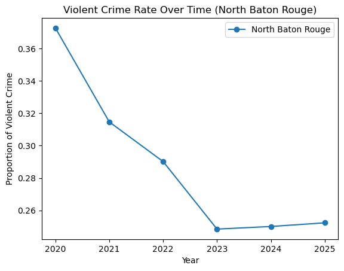

```python
nbr = crime[crime['NEIGHBORHOOD'] == 'NORTH BATON ROUGE']

violent_nbr = violent[violent['NEIGHBORHOOD'] == 'NORTH BATON ROUGE']

total_nbr = nbr.groupby('YEAR').size()
viol_counts_nbr = violent_nbr.groupby('YEAR').size()

viol_rate_nbr = viol_counts_nbr / total_nbr

viol_rate_nbr.plot(marker='o', label='North Baton Rouge')

plt.title("Violent Crime Rate Over Time (North Baton Rouge)")
plt.xlabel("Year")
plt.ylabel("Proportion of Violent Crime")
plt.legend()
plt.show()
```

However, caution should be taken when interpreting earlier years in the dataset. Lower data volume or incomplete reporting may make early values less representative of true crime patterns. If early data disproportionately reflects violent incidents, the observed decline may be partially influenced by changes in reporting rather than actual decreases in violent crime.

Additionally, external factors such as the COVID-19 pandemic may have influenced both crime patterns and reporting practices during this period. Changes in policing, public behavior, or data collection methods could contribute to the trends observed, particularly during the years of most significant change.

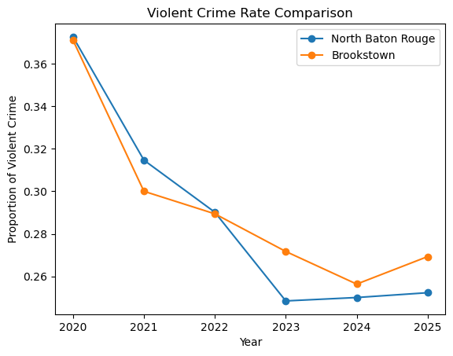

```python
bkt = crime[crime['NEIGHBORHOOD'] == 'BROOKSTOWN']
violent_bkt = violent[violent['NEIGHBORHOOD'] == 'BROOKSTOWN']

total_bkt = bkt.groupby('YEAR').size()
viol_counts_bkt = violent_bkt.groupby('YEAR').size()

viol_rate_bkt = (viol_counts_bkt / total_bkt).fillna(0)

viol_rate_nbr.plot(marker='o', label='North Baton Rouge')
viol_rate_bkt.plot(marker='o', label='Brookstown')

plt.title("Violent Crime Rate Comparison")
plt.xlabel("Year")
plt.ylabel("Proportion of Violent Crime")
plt.legend()
plt.show()
```

```python
categories = ['Property', 'Society', 'Violent']

categories = ['Property', 'Society', 'Violent']

violent_rate = combo['proportion']
viol_rate = violent_rate

nbr_values = [
    pivot_percent.loc['NORTH BATON ROUGE', 'PROPERTY'],
    pivot_percent.loc['NORTH BATON ROUGE', 'SOCIETY'],
    violent_rate.loc['NORTH BATON ROUGE']
]

bkt_values = [
    pivot_percent.loc['BROOKSTOWN', 'PROPERTY'],
    pivot_percent.loc['BROOKSTOWN', 'SOCIETY'],
    violent_rate.loc['BROOKSTOWN']
]

bkt_values = [
    pivot_percent.loc['BROOKSTOWN', 'PROPERTY'],
    pivot_percent.loc['BROOKSTOWN', 'SOCIETY'],
    viol_rate.loc['BROOKSTOWN']
]
```

```python
categories = ['Property', 'Society', 'Violent']

violent_rate = combo['proportion']

nbr_values = [
    pivot_percent.loc['NORTH BATON ROUGE', 'PROPERTY'],
    pivot_percent.loc['NORTH BATON ROUGE', 'SOCIETY'],
    violent_rate.loc['NORTH BATON ROUGE']
]

bkt_values = [
    pivot_percent.loc['BROOKSTOWN', 'PROPERTY'],
    pivot_percent.loc['BROOKSTOWN', 'SOCIETY'],
    violent_rate.loc['BROOKSTOWN']
]

x = np.arange(len(categories))
width = 0.35

plt.figure(figsize=(8,5))

plt.bar(x - width/2, nbr_values, width,
        color='darkred',
        label='North Baton Rouge')

plt.bar(x + width/2, bkt_values, width,
        color='navy',
        label='Brookstown')

plt.xticks(x, categories)
plt.xlabel("Crime Type")
plt.ylabel("Proportion")
plt.title("Crime Type Proportions by Neighborhood")
plt.ylim(0, 0.5)
plt.legend(title="Neighborhood")
plt.tight_layout()
plt.show()
```

[output not shown]

[output not shown]

## Conclusion

Using publicly available crime data, crime trends in Baton Rouge were analyzed. Crimes categorized as violent were compiled into a separate dataframe to compare violent crime rates across neighborhoods. Patterns in reported crime were explored with the goal of better understanding neighborhood-level violent crime risk within Baton Rouge.

Additional analysis would be valuable to further confirm and expand upon the trends identified in this project. Geographic mapping could provide deeper insight into spatial crime distribution across neighborhoods. Future analysis could also incorporate predictive modeling techniques to better understand crime trends and potentially support future policy or resource allocation decisions.

Overall, this project demonstrates how public crime data can be cleaned, analyzed, and interpreted to better understand neighborhood-level crime patterns and support future data-driven research.

## Limitations

The dataset used in this project was publicly sourced, meaning the consistency and completeness of the data could not be fully verified. Additionally, reported crimes are not representative of all crimes committed, as many incidents may go unreported. The classification of “violent” crimes also required interpretation and categorization decisions during the data-cleaning process, which may influence results.